# Goals of This File

1. Load the fastree unrooted tree.
2. Add tree to phyloseq object.
3. Visualize and inspect tree with ggtree
4. Prune ASVs , if needed.
5. Root our tree.
6. Combine new tree with a phyloseq object.
7. Save 2 phyloseq objects- one will be an Unrooted tree phyloseq object, the second will be a rooted tree phylosep object. If we want to use a dissimilarity metric that’s taking into account phylogeny, we will need a rooted tree because we need to know the tree branch lengths. It is very useful, we could calculate the phylogenetic hill numbers (look into). We will also need the unifrac dissimilarity for that. ## Set my seed

```r
# any number can be chosen (like b-day, or just hit random keys), use set.seed() from base R

set.seed(238428)
```

# Load Libraries

```r
pacman::p_load(tidyverse, phyloseq, ggtree, phytools, install=FALSE)
```

# Load Data Files

```r
#Preprocessed phyloseq object it's in our data folder
load("data/02_PreProcessing/raw_preprocessed_physeq.RData")
raw_preprocessed_physeq
```

```
## phyloseq-class experiment-level object
## otu_table()   OTU Table:         [ 2677 taxa and 89 samples ]
## sample_data() Sample Data:       [ 89 samples by 47 sample variables ]
## tax_table()   Taxonomy Table:    [ 2677 taxa by 9 taxonomic ranks ]
```

# Load in the tree, use the command from phytools read.tree

```r
unrooted_tree <- read.tree("data/03_Phylogenetic_Tree/ASVs_unrooted.tree")
str(unrooted_tree)
```

```
## List of 5
##  $ edge       : int [1:5351, 1:2] 2678 2679 2680 2681 2682 2682 2683 2683 2681 2684 ...
##  $ edge.length: num [1:5351] 0.00488 0.01347 0.01407 0.07983 0.06705 ...
##  $ Nnode      : int 2675
##  $ node.label : chr [1:2675] "" "0.571" "0.817" "0.729" ...
##  $ tip.label  : chr [1:2677] "ASV_2503" "ASV_726" "ASV_2376" "ASV_1095" ...
##  - attr(*, "class")= chr "phylo"
##  - attr(*, "order")= chr "cladewise"
```

```r
#edge length is the branch length

# It is an S4 data object, so everything in the tree has to match everything in the phyloseq object
```

# Merge Phyloseq

```r
#Intuition Check
stopifnot(ntaxa(raw_preprocessed_physeq)== ntaxa(unrooted_tree))

#Merge the tree with thte phyloseq object
unrooted_physeq<-
  merge_phyloseq(raw_preprocessed_physeq, unrooted_tree)
```

[output not shown]

[output not shown]

[output not shown]

[output not shown]

[output not shown]

[output not shown]

[output not shown]

[output not shown]

[output not shown]

[output not shown]

[output not shown]

[output not shown]

[output not shown]

[output not shown]

```r
unrooted_physeq
```

```
## phyloseq-class experiment-level object
## otu_table()   OTU Table:         [ 2677 taxa and 89 samples ]
## sample_data() Sample Data:       [ 89 samples by 47 sample variables ]
## tax_table()   Taxonomy Table:    [ 2677 taxa by 9 taxonomic ranks ]
## phy_tree()    Phylogenetic Tree: [ 2677 tips and 2675 internal nodes ]
```

```
## List of 1
##  $ legend.position: chr "bottom"
##  - attr(*, "class")= chr [1:2] "theme" "gg"
##  - attr(*, "complete")= logi FALSE
##  - attr(*, "validate")= logi TRUE
```

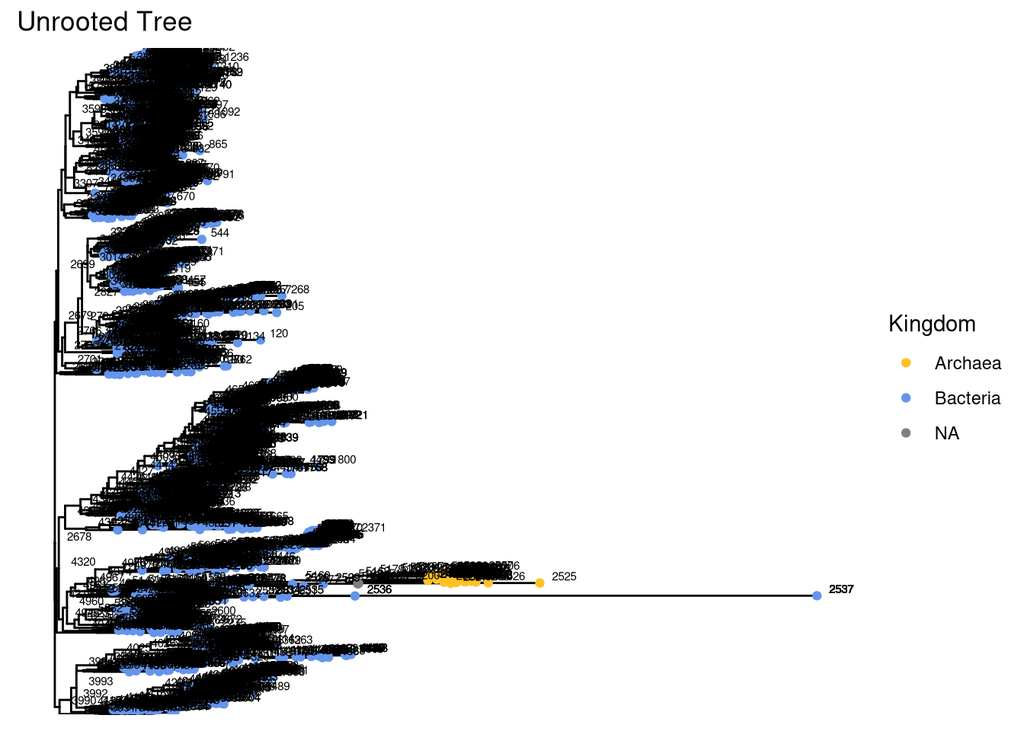

```r
#Make a basic tree
kingdom_node_tree <-ggtree(unrooted_physeq) +
  # color tips by kingdom
  geom_tippoint(mapping= aes(color = Kingdom)) +
  scale_color_manual(values = c("goldenrod1", "cornflowerblue", "grey")) +
  #Add title, add information at the nodes
  labs(title = "Unrooted Tree") +
  geom_text(aes(label=node), hjust= -0.5, vjust = -0.3, size = 2)
  theme(legend.position = "bottom") ; kingdom_node_tree
```

#There was one strange outlying branch, so let’s evaluate it: We need to know where to zoom in to inspect the tree. A reasonable hypothesis to make is where we have all of the NAs coming at the kingdom level, because the bases between those two groups could be harder to identify. It takes a lot of manual code.

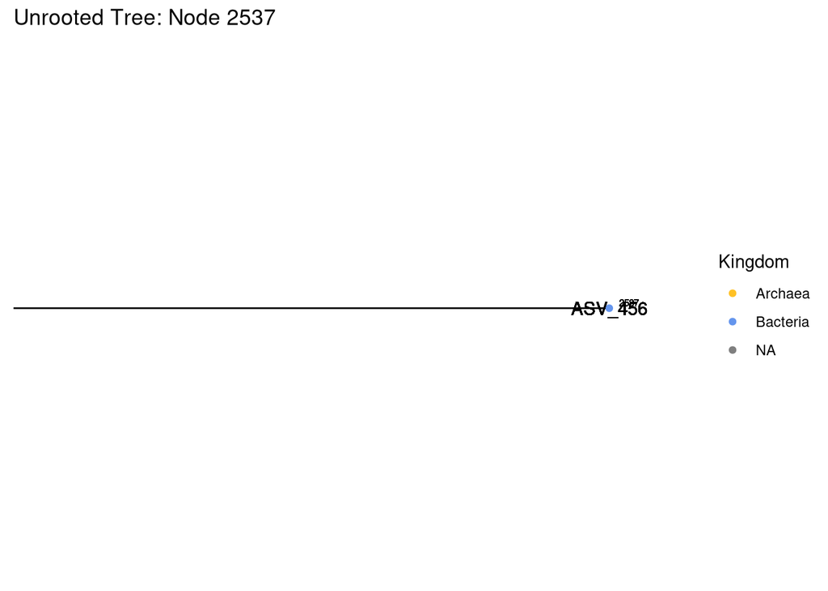

```r
#View a specific clade
#Zoom in on the original tree, and not the weird clade is 2537, so we'll use the command
viewClade(kingdom_node_tree + labs(title = "Unrooted Tree: Node 2537") + geom_text(aes(label=ASV)), node = 2537)
```

```r
# Use NCBI BLAST to paste in your sequence and find out what it is.
unrooted_physeq %>%
  subset_taxa(., ASV == "ASV_456") %>%
  tax_table() %>%
  data.frame()
```

```
## Found more than one class "phylo" in cache; using the first, from namespace 'phyloseq'
```

```
## Also defined by 'tidytree'
```

```
## Found more than one class "phylo" in cache; using the first, from namespace 'phyloseq'
```

```
## Also defined by 'tidytree'
```

```
##          Kingdom         Phylum               Class Order Family Genus Species
## ASV_456 Bacteria Proteobacteria Alphaproteobacteria  <NA>   <NA>  <NA>    <NA>
##             ASV
## ASV_456 ASV_456
##                                                                                                                                                                                                                                                            ASVseq
## ASV_456 GGGTGGGGCTAGCTTTTTCCAGAAGAAATCGGTGTTAAGCAGGGAAAGACGGAAAGATTT…
```

```r
# LEts also check the counts of the SV
unrooted_physeq %>%
  subset_taxa(., ASV == "ASV_456") %>%
  otu_table() %>%
  data.frame() %>%
  colSums()
```

```
## Found more than one class "phylo" in cache; using the first, from namespace 'phyloseq'
## Also defined by 'tidytree'
```

```
## Found more than one class "phylo" in cache; using the first, from namespace 'phyloseq'
```

```
## Also defined by 'tidytree'
```

```
## X20210602.MA.ABB1F X20210602.MA.ABB1P X20210602.MA.ABB1W X20210602.MA.ABS1F
##                  5                  0                  6                  0
## X20210602.MA.ABS1P X20210602.MA.ABS1W X20210602.MA.CEB1F X20210602.MA.CEB1P
##                  0                  8                  0                  0
## X20210602.MA.CEB1W X20210602.MA.CES1F X20210602.MA.CES1P X20210602.MA.CES1W
##                  0                  0                  0                  0
## X20210602.MA.CWB1F X20210602.MA.CWB1P X20210602.MA.CWB1W X20210602.MA.CWS1F
##                  0                  0                  0                  0
## X20210602.MA.CWS1P X20210602.MA.CWS1W X20210602.MA.MBB1F X20210602.MA.MBB1P
##                  0                  0                  7                  0
## X20210602.MA.MBB1W X20210602.MA.MBS1F X20210602.MA.MBS1P X20210602.MA.MBS1W
##                  0                  3                  0                  0
## X20210602.MA.SCB1F X20210602.MA.SCB1P X20210602.MA.SCB1W X20210602.MA.SCS1F
##                  0                  0                  0                  0
## X20210602.MA.SCS1P X20210602.MA.SCS1W X20210615.MA.ABB2F X20210615.MA.ABB2P
##                  0                  4                  0                  0
## X20210615.MA.ABB2W X20210615.MA.ABS1F X20210615.MA.ABS1P X20210615.MA.ABS1W
##                  0                  0                  0                  0
## X20210615.MA.CEB1F X20210615.MA.CEB1P X20210615.MA.CEB1W X20210615.MA.CES1F
##                  0                  0                  0                  0
## X20210615.MA.CES1P X20210615.MA.CES1W X20210615.MA.CWB1F X20210615.MA.CWB1P
##                  0                  0                  0                  0
## X20210615.MA.CWB1W X20210615.MA.CWS1F X20210615.MA.CWS1P X20210615.MA.CWS1W
##                  0                  0                  0                  0
## X20210615.MA.MBB1F X20210615.MA.MBB1P X20210615.MA.MBB1W X20210615.MA.MBS1F
##                  0                  0                  0                  0
## X20210615.MA.MBS1P X20210615.MA.MBS1W X20210615.MA.SCB2P X20210615.MA.SCB2W
##                  0                  0                  0                  0
## X20210615.MA.SCS2F X20210615.MA.SCS2P X20210615.MA.SCS2W X20211005.MA.ABB2F
##                  0                  0                  0                  0
## X20211005.MA.ABB2P X20211005.MA.ABB2W X20211005.MA.ABS1F X20211005.MA.ABS1P
##                  0                  0                  0                  0
## X20211005.MA.ABS1W X20211005.MA.CEB1F X20211005.MA.CEB1P X20211005.MA.CEB1W
##                  0                  4                  0                  0
## X20211005.MA.CES2F X20211005.MA.CES2P X20211005.MA.CES2W X20211005.MA.CWB1F
##                  0                  0                  0                  0
## X20211005.MA.CWB1P X20211005.MA.CWB1W X20211005.MA.CWS1F X20211005.MA.CWS1P
##                  0                  0                  0                  0
## X20211005.MA.CWS1W X20211005.MA.MBB1F X20211005.MA.MBB1P X20211005.MA.MBB1W
##                  0                 14                  0                  7
## X20211005.MA.MBS1F X20211005.MA.MBS1P X20211005.MA.MBS1W X20211005.MA.SCB1F
##                  8                 10                  8                  0
## X20211005.MA.SCB1P X20211005.MA.SCB1W X20211005.MA.SCS2F X20211005.MA.SCS2P
##                  0                  0                  0                  0
## X20211005.MA.SCS2W
##                  0
```

It turns out that was a mitochondrion (the way far outlier), a contaminant that we need to prune out thusly:

```r
#Subset Tree- Take a phyloseq object and subset out anything that doesn't
# Function from Joey McMurdie: https://github.com/joey711/phyloseq/issues/652 (include link where you found the code in your document)
pop_taxa = function(physeq, badTaxa){
  allTaxa <-  taxa_names(physeq)
  allTaxa <- allTaxa[!(allTaxa %in% badTaxa)]
  return(prune_taxa(allTaxa, physeq))}

#Let's use the pop_taxa function-- We'll re-create a phyloseq object without ASV 456.
unrooted_physeq_rm456 <-unrooted_physeq %>%
  pop_taxa(., "ASV_456")
```

```
## Found more than one class "phylo" in cache; using the first, from namespace 'phyloseq'
```

```
## Also defined by 'tidytree'
```

```r
#Since phyloseq has pretty stringent things, we don't have to worry about the warning
#Intuition Check
ntaxa(unrooted_physeq) - ntaxa(unrooted_physeq_rm456)
```

```
## [1] 1
```

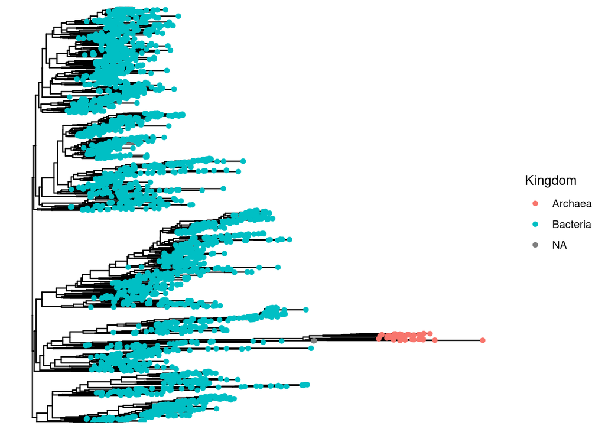

```r
#visually check
ggtree(unrooted_physeq_rm456) + geom_tippoint(mapping=aes(color= Kingdom))
```

THen we can make a rooted tree– our unrooted tree has Archae in the middle of the tree, but they should be an out group. We need to root because we’re going to use a weighted unifrac to look at the beta diversity in our samples.

# Midroot Tree

(We could try to root with Archaea, midrooting is one of the most common ways of rooting the tree. THen we’ll export and do Betadiversity)

```r
# Is the tree rooted? Phyloseq likes to call the tree object phy_tree, so we'll use that
new_unrooted_tree <- phy_tree(unrooted_physeq_rm456)
is.rooted(phy_tree(new_unrooted_tree))
```

```
## [1] FALSE
```

```r
# get an output of false, so lett' midpoint root the tree using midpoint.root function in phytools package can be used to newly root or re-root a tree
midpoint_rooted_tree<- midpoint.root(new_unrooted_tree)

#Assign to a new phyloseq object: merging subsetted phyloseq with the new rooted tree
# 1. Create the phyloseq object wihout ASV_456
physeq_rm456 <-raw_preprocessed_physeq %>%
  subset_taxa(ASV != "ASV_456")

#Merge tree with the new physeq_rm456
midroot_physeq_rm456 <- merge_phyloseq(physeq_rm456, midpoint_rooted_tree)
```

[output not shown]

[output not shown]

[output not shown]

[output not shown]

[output not shown]

[output not shown]

[output not shown]

[output not shown]

```r
midroot_physeq_rm456
```

```
## phyloseq-class experiment-level object
## otu_table()   OTU Table:         [ 2676 taxa and 89 samples ]
## sample_data() Sample Data:       [ 89 samples by 47 sample variables ]
## tax_table()   Taxonomy Table:    [ 2676 taxa by 9 taxonomic ranks ]
## phy_tree()    Phylogenetic Tree: [ 2676 tips and 2675 internal nodes ]
```

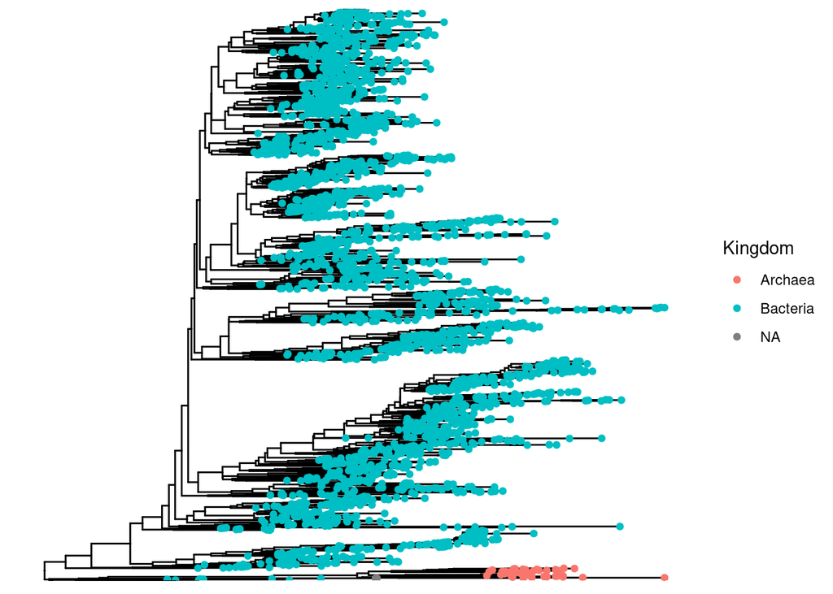

```r
#Quick inspection of tree (we always want to further confirm that it does have a root)
ggtree(midroot_physeq_rm456) +
  geom_tippoint(mapping= aes(color = Kingdom))
```

# We could do a similar approach, where we just root it within the Archea, we could remove all of the Archea, but we need this before calculating unifrac distances.

# Save to a new phyloseq object

```r
save(list = c("unrooted_physeq_rm456", "midroot_physeq_rm456"), file = "data/03_Phylogenetic_Tree/phytree_preprocessed_physeq.RData")
```